# Patient Adherence Analysis

Natalie Youngquist

Before doing any analysis on the models, I wanted to confirm that the data had loaded as expected.

```r
# confirm the data has loaded as expected
cat("Training Rows:", nrow(patient_train), "\n")
```

```
## Training Rows: 3304
```

```r
cat("Testing Rows:", nrow(patient_test), "\n")
```

```
## Testing Rows: 826
```

## Model Evaluation on Training Data

I then fit each model with the training data to measure the response and compared the AUC scores of the Logistic Regression, Random Forest, and Gradient Boosting models.

```r
# Logistic AIC Train AUC
pred_train_lr <- predict(model_lr, type = "response")
auc_train_lr <- auc(patient_train$adherent_binary, pred_train_lr)

# Random Forest Train AUC
pred_train_rf <- predict(model_rf, type = "prob")[, 2]
auc_train_rf <- auc(patient_train$adherent_binary, pred_train_rf)

# Gradient Boosting Train AUC
pred_train_gbm <- predict(model_gbm, newdata = patient_train, n.trees = 500, type = "response")
auc_train_gbm <- auc(patient_train$adherent_binary, pred_train_gbm)

# Build Comparison Table
auc_table <- tibble(
  Model = c("Logistic Regression (AIC)", "Random Forest", "Gradient Boosting"),
  AUC   = c(auc_train_lr, auc_train_rf, auc_train_gbm)
)

# compare AUC values
auc_table <- tibble(
  Model = c("Logistic Regression", "Random Forest", "Gradient Boosting"),
  AUC   = c(round(auc_train_lr, digits = 4), round(auc_train_rf, digits = 4), round(auc_train_gbm, digits = 4)
))

auc_table
```

```
## # A tibble: 3 × 2
##   Model                 AUC
##   <chr>               <dbl>
## 1 Logistic Regression 0.774
## 2 Random Forest       0.859
## 3 Gradient Boosting   0.872
```

### Choosing Models

Based on the AUC scores, I chose to continue evaluating the Logistic Regression model, and the Gradient Boosting model. Random Forest performed adequately, but not as well as Gradient Boosting. I continued with Logistic Regression because it is the simpler model and I wanted to see if the complexity from the Gradient Boosting was necessary when compared to the results of the Logistic Regression model.

```r
# extract model results on training data
results_lr  <- evaluate_lr(model_lr, patient_train, "adherent_binary")
results_gbm <- evaluate_gbm(model_gbm, patient_train, "adherent_binary", 500)
```

I calculated the percentage of correct predictions on the training data using the Logistic Regression model.

The confusion matrix for the Logistic Regression model indicated that:

- **Correct adherence predictions:** 86.99%
- **Correct non-adherence predictions:** 61.00%

```r
# logistic regression performance on training data
#print(results_lr$confusion_matrix)
percent_correct(patient_train$adherent_binary, results_lr$predict_class)
```

```
##              Class Correct Total Percent_Correct
## 1     1 (Adherent)    1799  2068           86.99
## 2 0 (Non-Adherent)     754  1236           61.00
```

#### Evaluating Gradient Boosting Model

I then calculated the percentage of correct predictions on the training data using the Gradient Boosting model.

The confusion matrix for the Gradient Boosting model indicated that:

- **Correct adherence predictions:** 90.23%
- **Correct non-adherence predictions:** 65.53%

The Gradient Boosting model was **3.24%** more accurate at predicting adherent patients and **4.53%%** more accurate at predicting non-adherent patients.

```r
# gradient boosting performance on training data
#print(results_gbm$confusion_matrix)
percent_correct(patient_train$adherent_binary, results_gbm$predict_class)
```

```
##              Class Correct Total Percent_Correct
## 1     1 (Adherent)    1866  2068           90.23
## 2 0 (Non-Adherent)     810  1236           65.53
```

#### Visualizing ROC Curve for Both Models

I also plotted the ROC curve to visualize model accuracy on the training data.

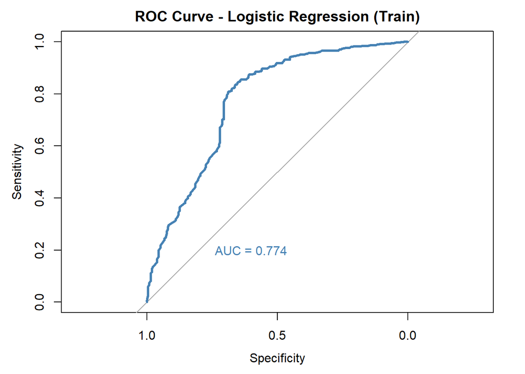

```r
# in sample ROC curves
plot_roc_curve(results_lr$roc, results_lr$auc, "Logistic Regression (Train)")
```

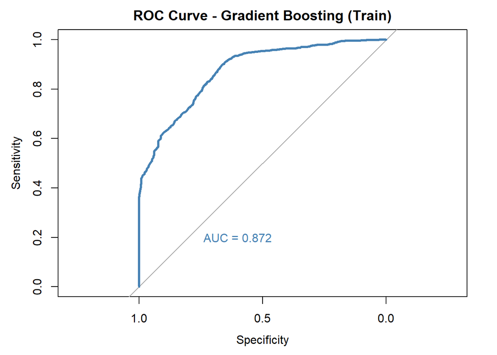

```r
plot_roc_curve(results_gbm$roc, results_gbm$auc, "Gradient Boosting (Train)")
```

Having performed robust evaluation on the models using the training data, I then moved on to evaluation the models using the testing data.

## Model Evaluation on Testing Data

```r
# extract model results on test data
results_lr_test  <- evaluate_lr(model_lr, patient_test, "adherent_binary")
results_gbm_test <- evaluate_gbm(model_gbm, patient_test, "adherent_binary", 500)
```

I calculated the percentage of correct predictions on the testing data using the Logistic Regression model.

The confusion matrix for the Logistic Regression model indicated that:

- **Correct adherence predictions:** 84.66%
- **Correct non-adherence predictions:** 59.40%

```r
# logistic regression accuracy on test data
#print(results_lr_test$confusion_matrix)
percent_correct(patient_test$adherent_binary, results_lr_test$predict_class)
```

```
##              Class Correct Total Percent_Correct
## 1     1 (Adherent)     447   528           84.66
## 2 0 (Non-Adherent)     177   298           59.40
```

#### Evaluating Gradient Boosting Model

I then calculated the percentage of correct predictions on the testing data using the Gradient Boosting model.

The confusion matrix for the Gradient Boosting model indicated that:

- **Correct adherence predictions:** 88.83%
- **Correct non-adherence predictions:** 62.08%

The Gradient Boosting model was **4.17%** more accurate at predicting adherent patients and **2.68%%** more accurate at predicting non-adherent patients.

```r
# gradient boosting accuracy on test data
#print(results_gbm_test$confusion_matrix)
percent_correct(patient_test$adherent_binary, results_gbm_test$predict_class)
```

```
##              Class Correct Total Percent_Correct
## 1     1 (Adherent)     469   528           88.83
## 2 0 (Non-Adherent)     185   298           62.08
```

#### Percentage of Incorrect Predictions by Each Model

I also wanted to know the percentage of incorrect predictions for each model. I started with Logistic Regression.

The confusion matrix for the Logistic Regression model indicated that:

- **Incorrect adherence predictions:** 15.34%
- **Incorrect non-adherence predictions:** 40.60%

```r
# logistic regression errors on test data
percent_incorrect(patient_test$adherent_binary, results_lr_test$predict_class)
```

```
##              Class Incorrect Total Percent_Incorrect
## 1     1 (Adherent)        81   528             15.34
## 2 0 (Non-Adherent)       121   298             40.60
```

And then evaluated the percentage of incorrect predictions on Gradient Boosting.

The confusion matrix for the Gradient Boosting model indicated that:

- **Incorrect adherence predictions:** 11.17%
- **Incorrect non-adherence predictions:** 37.92%

```r
# gradient boosting errors on test data
percent_incorrect(patient_test$adherent_binary, results_gbm_test$predict_class)
```

```
##              Class Incorrect Total Percent_Incorrect
## 1     1 (Adherent)        59   528             11.17
## 2 0 (Non-Adherent)       113   298             37.92
```

For a clear comparison, I reviewed the percentage of overall accuracy for each model. Gradient Boosting was more accurate by **3.64%**.

```r
# overall accuracy on test data
percent_corr_lr  <- total_percent_correct(patient_test$adherent_binary, results_lr_test$predict_class)
percent_corr_gbm <- total_percent_correct(patient_test$adherent_binary, results_gbm_test$predict_class)

cat("Logistic Regression Overall Accuracy:", round(percent_corr_lr, 2), "%\n")
```

```
## Logistic Regression Overall Accuracy: 75.54 %
```

```r
cat("Gradient Boosting Overall Accuracy:", round(percent_corr_gbm, 2), "%\n")
```

```
## Gradient Boosting Overall Accuracy: 79.18 %
```

#### Visualizing ROC Curve for Both Models

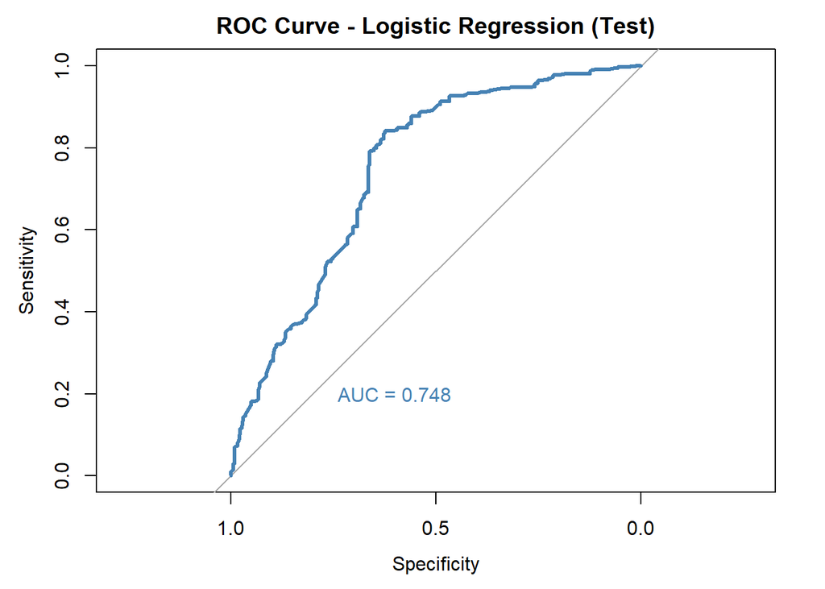

```r
# out of sample ROC curves
plot_roc_curve(results_lr_test$roc, results_lr_test$auc, "Logistic Regression (Test)")
```

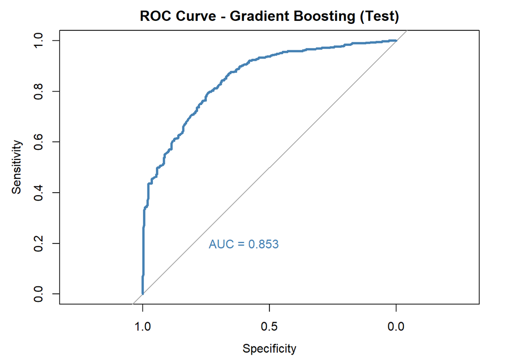

```r
plot_roc_curve(results_gbm_test$roc, results_gbm_test$auc, "Gradient Boosting (Test)")
```

### False Non-Adherent Predictions Handling

Predicting a patient is non-adherent when they are actually adherent can lead to significant patient frustration. If an adherent patient experience unresolved ailments or side effects, a correct adherence prediction allows the doctor to rule out inconsistent medication usage as the cause. An incorrect prediction of non-adherence might cause a provider to dismiss these symptoms as a result of poor compliance, damaging the provider-patient trust relationship.

### False Adherent Predictions Handling

Predicting a patient is adherent when they are actually non-adherent is clinically dangerous. It represents a missed opportunity for proactive identification. When a non-adherent patient is flagged as adherent, they do not receive the necessary resources, encouragement, or counseling required to improve their health outcomes, leaving underlying medical issues unaddressed.

## Summary

The choice of model should be dictated by the clinical goal. If the objective is maximum accuracy for a high-risk intervention program, the Gradient Boosting model is superior. If the goal is a cost-effective, explainable baseline that allows providers to clearly see the “why” behind a risk score, Logistic Regression remains a highly effective model.